# Section 8 Report

Michael Masterson

13 August, 2020

**Be sure you have states.csv, state_level.csv, individual_level.csv, vote.csv, war.csv, p4v2017.csv, and NMC4.csv in your data folder before starting this section.**

# Load Polity

Polity is a data set that contains regime data at the country-year unit of analysis.

We care about the ccode variable that labels the country the data is about, the year variable that indicates which year the data is from, and polity that ranks countries from -10 to 10 on how democratic they are. Lets simplify to just those variables.

```r
polity.data <- read_csv(here("data", "p4v2017.csv"))
polity.data <- select(polity.data, ccode, country, year, polity)
```

We can examine the data with include=FALSE, so that the data frame will not print to our knitted document.

The minimum of polity is -88. This is a problem because polity should never be < -10. Are there other problem values?

Yes there is also -77.

# Recode and Fix Missing Values with case_when()

We need to convert -77 and -88, which the code book says indicate missing values, to NA. What if we also want to change polity into a variable that indicates whether or not a country is a democracy? Lets define countries with 6 and above on polity as democracies. We can do both of these things with case_when().

case_when() takes a series of formulas where the left hand side is a logical test, and the right hand side is the value to return.

```r
polity.data <- mutate(polity.data,
                      #first just fix polity
                      polity = case_when(
                        #you cannot just use NA for case_when
                        #it must match the datatype of the rest of the values
                        polity < -10 ~ NA_real_,
                        TRUE ~ polity),
                      #you can have more than 2 cases
                      demo  = case_when(
                        polity > 5 ~ 1,
                        polity < 6 ~ 0,
                        TRUE ~ NA_real_)) #Your last one should be a catchall TRUE

summary(polity.data)
```

```
##      ccode         country               year          polity
##  Min.   :  2.0   Length:17395       Min.   :1800   Min.   :-10.000
##  1st Qu.:200.0   Class :character   1st Qu.:1894   1st Qu.: -7.000
##  Median :366.0   Mode  :character   Median :1959   Median : -3.000
##  Mean   :404.2                      Mean   :1940   Mean   : -0.495
##  3rd Qu.:630.0                      3rd Qu.:1991   3rd Qu.:  7.000
##  Max.   :950.0                      Max.   :2017   Max.   : 10.000
##                                                    NA's   :776
##       demo
##  Min.   :0.0000
##  1st Qu.:0.0000
##  Median :0.0000
##  Mean   :0.3027
##  3rd Qu.:1.0000
##  Max.   :1.0000
##  NA's   :776
```

# Load NMC data

The second data frame we want to work with is country-year level data on military capabilities.

```r
nmc.data <-read_csv(here("data", "NMC4.csv"))
```

We only care about the variables ccode, year, and milex, which is how much a country spent on the military in a year.

Lets simplify.

```r
nmc.data <- select(nmc.data,
                   ccode, year, milex)
```

Lets examine the data.

milex should never be negative. Are there any other problem values?

We can fix it the same way with mutate and case_when.

```r
nmc.data <- mutate(nmc.data,
                  milex = case_when(milex < 0 ~ NA_real_,
                                    TRUE ~ milex))

#its okay now
summary(nmc.data)
```

```
##      ccode            year          milex
##  Min.   :  2.0   Min.   :1816   Min.   :        0
##  1st Qu.:165.0   1st Qu.:1914   1st Qu.:     4912
##  Median :355.0   Median :1964   Median :    42743
##  Mean   :390.5   Mean   :1947   Mean   :  2594060
##  3rd Qu.:615.0   3rd Qu.:1988   3rd Qu.:   442350
##  Max.   :990.0   Max.   :2007   Max.   :552568000
##                                 NA's   :1972
```

# inner_join Dataframes

To join data frames they must be at the same unit of analysis. The variable(s) that label unique rows need to have the same name(s).

Both polity and nmc are at the country-year level and have variables labeled ccode and year that identify each row. What if the variables are named different? We can rename them like this.

```r
polity.data <- rename(polity.data, year = year)
```

To join the data frames we can use the inner_join() function. inner_join takes as arguments the data frames you want to join and a by argument that is the name(s) of the variable(s) that identify each row in quotes. If there is more than 1 variable, they must be concatenated.

```r
joined.data <- inner_join(polity.data, nmc.data, by = c("ccode", "year"))
```

inner_join will only include rows that contain data from each table! Even though polity starts in 1800, NMC does not start until 1816, so that is where our joined data set starts.

```r
summary(joined.data$year)
```

```
##    Min. 1st Qu.  Median    Mean 3rd Qu.    Max.
##    1816    1917    1963    1947    1987    2007
```

There is an exact way we can compare variables from our original data frame and our new joined data frame to see what rows, if any, the joined data frame has thrown out. To do this, use the setdiff() function.

```r
setdiff(polity.data$year, joined.data$year)
```

```
##  [1] 1800 1801 1802 1803 1804 1805 1806 1807 1808 1809 1810 1811 1812 1813
## [15] 1814 1815 2008 2009 2010 2011 2012 2013 2014 2015 2016 2017
```

# Practice 1

1. Read states.csv and vote.csv into separate R objects.
2. Join the data frames using inner_join()
3. Does the joined_data frame contain all the original rows? If any differ, what is the state_id of the row that is different?

# left_joint

Read in war.csv as a tibble. Each row in this data set is a war. The unit of observations is war.

```r
war.data <- select(war.data, ccode, StartYear1)
```

Rename variables as needed.

```r
war.data <- rename(war.data, year = StartYear1)
```

We need a variable that records a war happened, *but* first we should check whether there are some years where more than 1 war happened with a single country.

There are, so we have to be careful. We need to make a variable that sums wars grouped by both ccode and year and then put that variable at the same level of analysis as the original data.

First lets just make a war indicator. Every row in war.data is a war, so we will make a variable that is 1 for all rows to indicate a war happened.

```r
war.data <- mutate(war.data,
                   war = 1)
```

We can group_by() multiple variables to count total number of wars that happened in a particular country-year.

```r
war.data <- war.data %>%
  group_by(ccode, year) %>%
  # group_by(year) %>%
  mutate(num_wars = sum(war)) %>%
  # we can ungroup to get back to the level of the original dataset
  ungroup()


summary(war.data)
```

```
##      ccode            year           war       num_wars
##  Min.   :  2.0   Min.   :1823   Min.   :1   Min.   :1.000
##  1st Qu.:220.0   1st Qu.:1900   1st Qu.:1   1st Qu.:1.000
##  Median :355.0   Median :1939   Median :1   Median :1.000
##  Mean   :419.9   Mean   :1931   Mean   :1   Mean   :1.047
##  3rd Qu.:652.0   3rd Qu.:1969   3rd Qu.:1   3rd Qu.:1.000
##  Max.   :920.0   Max.   :2003   Max.   :1   Max.   :2.000
```

Now we can join this with our NMC data, but *wait,* war data is only 337 rows. If we use inner_join() we will be throwing out a lot of rows where we actually have data. What we want to do is keep all the rows from nmc.data and use the war.data to fill values in where we can. To do this, we can use left_join() to include all rows from the first data set and only matching rows from the second data set.

```r
warjoin <- left_join(nmc.data, war.data, by = c("ccode", "year"))
```

Lastly, we need to recode NA on war and numwars to 0. This is because every observation in our war data was a war. We have no observations for country-years that are not wars. This means, if an observation is missing for our war variable, that no war took place.

```r
warjoin <- mutate(warjoin,
                  war = case_when(
                    is.na(war) ~ 0,
                    TRUE ~ war
                  ),
                  num_wars = case_when(
                    is.na(num_wars) ~ 0,
                    TRUE ~ num_wars
                  ))

warjoin
```

```
## # A tibble: 14,207 x 5
##    ccode  year milex   war num_wars
##    <dbl> <dbl> <dbl> <dbl>    <dbl>
##  1     2  1816  3823     0        0
##  2     2  1817  2466     0        0
##  3     2  1818  1910     0        0
##  4     2  1819  2301     0        0
##  5     2  1820  1556     0        0
##  6     2  1821  1612     0        0
##  7     2  1822  1079     0        0
##  8     2  1823  1170     0        0
##  9     2  1824  1261     0        0
## 10     2  1825  1336     0        0
## # … with 14,197 more rows
```

```r
summary(warjoin)
```

```
##      ccode            year          milex                war
##  Min.   :  2.0   Min.   :1816   Min.   :        0   Min.   :0.00000
##  1st Qu.:165.0   1st Qu.:1914   1st Qu.:     4916   1st Qu.:0.00000
##  Median :355.0   Median :1964   Median :    42770   Median :0.00000
##  Mean   :390.6   Mean   :1946   Mean   :  2593359   Mean   :0.02372
##  3rd Qu.:615.0   3rd Qu.:1988   3rd Qu.:   442350   3rd Qu.:0.00000
##  Max.   :990.0   Max.   :2007   Max.   :552568000   Max.   :1.00000
##                                 NA's   :1972
##     num_wars
##  Min.   :0.00000
##  1st Qu.:0.00000
##  Median :0.00000
##  Mean   :0.02485
##  3rd Qu.:0.00000
##  Max.   :2.00000
##
```

# Practice 2

You want to see if states where more people like the color red also tend to vote more Republican. You have individual-level polling data on how much people like red on a scale of 1-10 and state-level data on the percentage that vote for the GOP.

1. Read individual_level.csv and state_level.csv into 2 separate R objects.
2. Use group_by and summarize to create a state-level data set of people’s average color preferences by state.
3. Join the two data frames using inner_join().
4. If you had used left_join() instead, would the result have been different? Why or why not?

# Nonlinear Relationships

Lets make a GDP variable in gapminder.

```r
gapminder <- mutate(gapminder,
  gdp = pop * gdpPercap
)
```

Now lets make variables that are the natural log of pop and gdp.

```r
gapminder <-mutate(gapminder,
                   log_pop = log(pop),
                   log_gdp = log(gdp))
```

Remember how in a previous section when we tried to explain life expectancy with gdp we did not do very well. Our model predicted that people in rich countries would live to over 125. The problem is that the relationship between wealth and life expectancy is not linear. After wealth increases beyond a certain point, it does not really make people live longer. Often, taking the natural log of the independent variable is a good way to model relationships like this.

```r
model.ols2 <-lm(lifeExp ~ log_gdp + log_pop, data = gapminder)
tidy(model.ols2)
```

```
## # A tibble: 3 x 5
##   term        estimate std.error statistic   p.value
##   <chr>          <dbl>     <dbl>     <dbl>     <dbl>
## 1 (Intercept)   -28.8      2.08      -13.9 1.78e- 41
## 2 log_gdp         8.34     0.143      58.2 0.
## 3 log_pop        -7.07     0.185     -38.3 6.75e-232
```

## Multiple Prediction with log-linear Relationships

We want to see the effect of log_GDP holding log population constant! We should hold population at its mean.

First make a data frame prediction data frame from original data.

```r
prediction.data <- gapminder
```

Now set log_pop to its mean for every row.

```r
prediction.data <- mutate(prediction.data,
                         log_pop = mean(log_pop))
```

Now we can use augment to predict using our new prediction data!

```r
model2.predict <- augment(model.ols2, newdata = prediction.data)
```

We should calculate our confidence interval. We can do this the same way we always have.

```r
model2.predict <- mutate(model2.predict,
                         upperbound = .fitted + (.se.fit * 1.96),
                         lowerbound = .fitted - (.se.fit * 1.96))
```

Lets make a graph of our predictions.

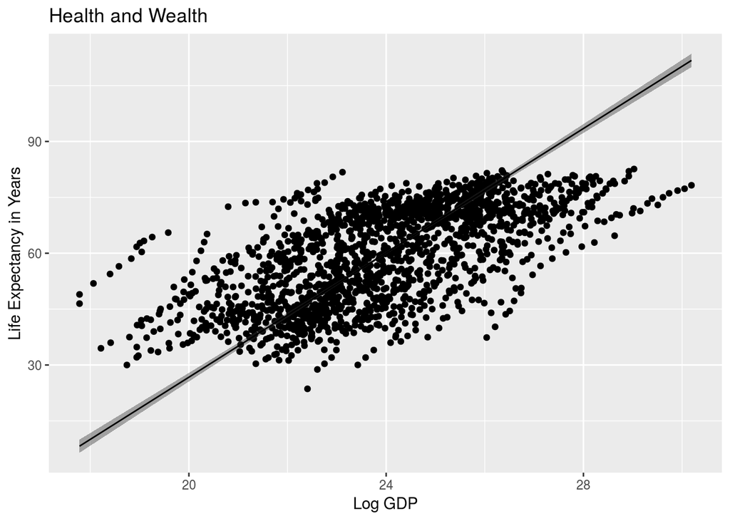

```r
ggplot(data = model2.predict, aes(x = log_gdp, y = lifeExp)) +
  geom_point()+
  geom_ribbon(aes(ymin = lowerbound, ymax = upperbound), alpha = 0.4) +
  geom_line(aes(y = .fitted)) +
labs(x = "Log GDP", y = "Life Expectancy in Years",
     title = "Health and Wealth")
```

We can do even better than this. Log gdp might be difficult for our audience to interpret. We can re-scale the x axis.

First, we can use the exponentiation function exp() to reverse taking the log to get back our original gdp variable. Next we can put our gdp variable on the scale of billions of dollars instead of just dollars by dividing by 1 billion.

```r
model2.predict <-mutate(model2.predict,
                          gdp = exp(log_gdp),
                        gdp_billions = gdp / 1000000000)
```

Now we can graph using this new scale.

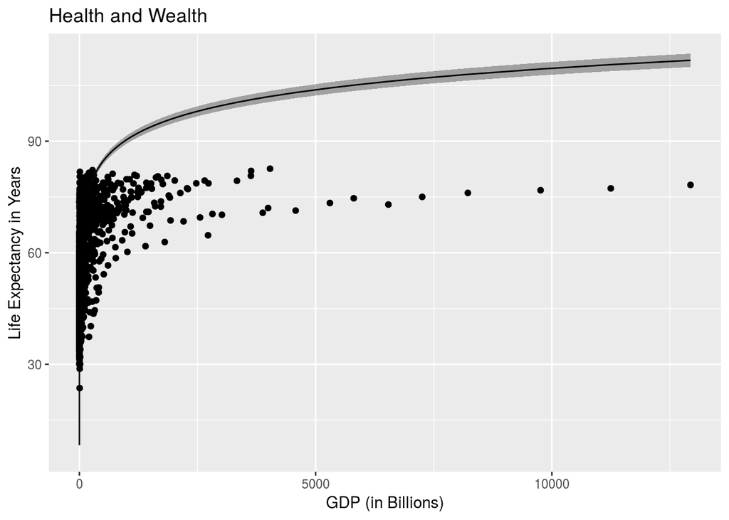

```r
ggplot(data = model2.predict, aes(x = gdp_billions, y = lifeExp)) +
  geom_point() +
  geom_ribbon(aes(ymin = lowerbound, ymax = upperbound), alpha = 0.4) +
  geom_line(aes(y=.fitted)) +
  labs(x = "GDP (in Billions)", y = "Life Expectancy in Years",
     title = "Health and Wealth")
```

# Practice 3

You want to make a similar graph based on model.ols2 showing the effect of population on life expectancy holding gdp constant.

1. Create a data frame that has the necessary variables and holds log_gdp to its mean value.
2. Using Augment(), use model.ols2 to predict on this new data frame.
3. Calculate the confidence interval.
4. Create a variable called pop_mil that is population in millions. Hint: remember to exponentiate log_pop first.
5. Graph the predicted value of life expectancy with a confidence interval across pop_mil.